# Differential expression analysis with edgeR

John Blischak

2016-04-26

In this tutorial, we will perform a basic differential expression analysis with RNA sequencing data using [R/Bioconductor](http://www.bioconductor.org). Before class, please download the data set and install the software as explained in the following section.

## Download data and install software

For this tutorial, we will use the data set generated by the Sequencing Quality Control ([SEQC](http://www.fda.gov/ScienceResearch/BioinformaticsTools/MicroarrayQualityControlProject/)) project. Please download the data by running the line of R code below. If this fails, you can try changing the `method` parameter, e.g. `method = "auto"`, `method = "wget"` or `method = "curl"`. And as a last resort, you can download it by clicking on this [link](https://www.ncbi.nlm.nih.gov/geo/download/?acc=GSE49712&format=file&file=GSE49712_HTSeq.txt.gz).

```r
fname <- "http://www.ncbi.nlm.nih.gov/geo/download/?acc=GSE49712&format=file&file=GSE49712_HTSeq.txt.gz"
download.file(fname, destfile = "GSE49712_HTSeq.txt.gz")
```

Next, we need to download and install the package we will use to perform the analysis: [edgeR](http://www.bioconductor.org/packages/release/bioc/html/edgeR.html).

```r
source("http://bioconductor.org/biocLite.R")
biocLite("edgeR", dependencies = TRUE)
```

## Introduction

As you learned in class, RNA sequencing (RNA-seq) is an experimental method for measuring RNA expression levels via high-throughput sequencing of small adapter-ligated fragments (see figure below from Wang, Gerstein, and Snyder (2009)). The number of reads that map to a gene is the proxy for its expression level.

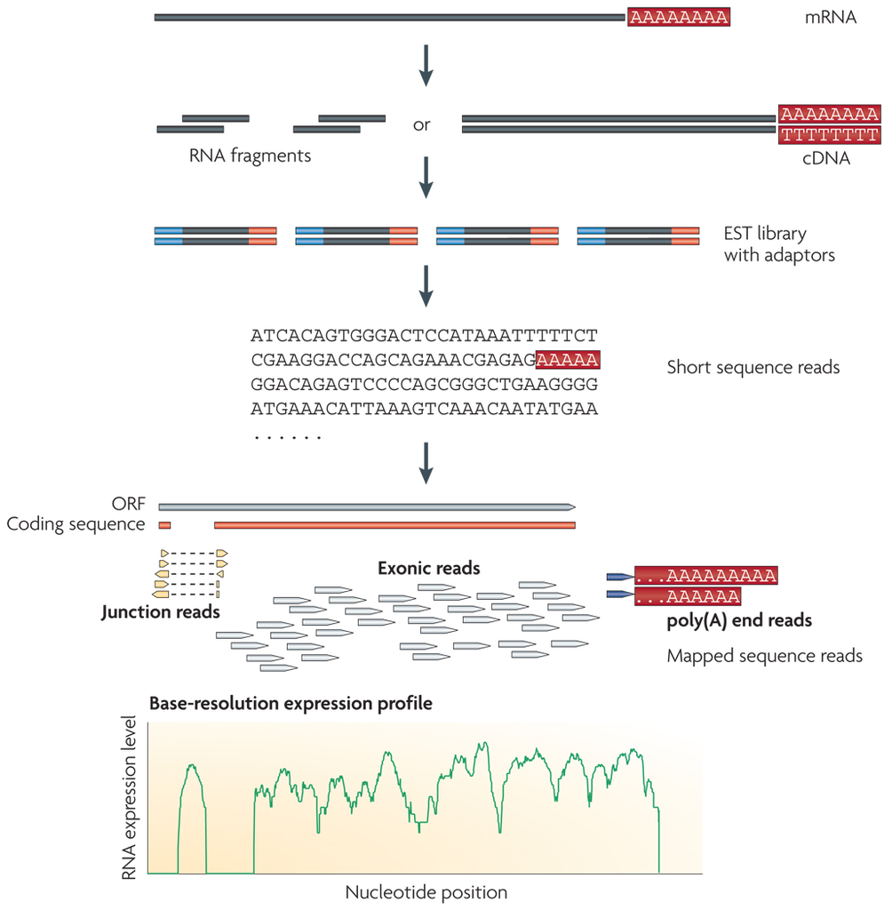

RNA-seq experiment

There are many steps between receiving the raw reads from the sequencer and gaining biological insight. In this tutorial, we will start with a “Table of counts” and end with a “List of differentially expressed genes”, as diagrammed in the RNA-seq analysis pipeline below (from Oshlack, Robinson, and Young (2010)).

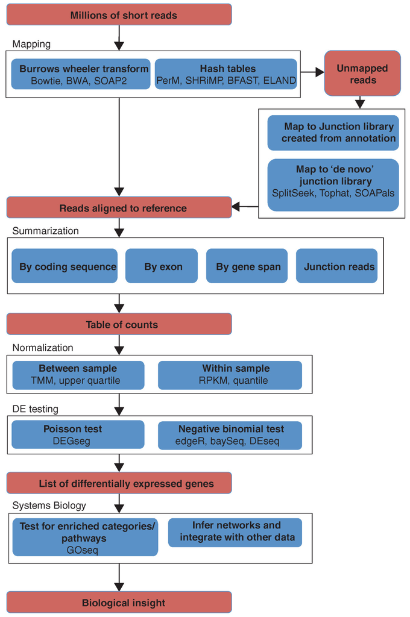

RNA-seq analysis pipeline

Unlike the continuous data that is generated by microarrays, RNA-seq generates counts. While it is possible to transform the counts into a continuous distribution and perform an analysis similar to microarrays, e.g. linear regression, multiple approaches have been developed to directly model the data as counts (Marioni, Mason, Mane, Stephens, and Gilad (2008)). We will perform a simple analysis using one popular Bioconductor package for differential expression analysis, [edgeR](http://www.bioconductor.org/packages/release/bioc/html/edgeR.html). edgeR (Robinson and Smyth (2007); Robinson, McCarthy, and Smyth (2009)) models the count data with a [negative binomial model](http://en.wikipedia.org/wiki/Negative_binomial_distribution).

The SEQC data set we will analyze contains two different groups for comparison. Group A is five technical replicates of the [Stratagene Universal Human Reference RNA](http://www.chem.agilent.com/Library/usermanuals/Public/740000.pdf). It is an equal mixture of RNA from ten different human cell lines. Group B is five technical replicates of [Ambion’s Human Brain Reference RNA](http://www.lifetechnologies.com/order/catalog/product/AM6050). It is RNA that was pooled from several donors from several different regions of the brain.

## Setup

First, we need to load the package into R.

```r
library("edgeR")
```

Second, we need to load the data into R. In order to use the code below, we need to ensure the data file is in R’s working directory. We can check our current working directory with the command `getwd()`, and we can change it using `setwd("path/to/file")` or using RStudio (type Ctrl-Shift-K).

```r
data_raw <- read.table("GSE49712_HTSeq.txt.gz", header = TRUE)
```

## Quality control

Let’s quickly explore the data. Each each row corresponds to a gene, and each column corresponds to a sample.

```r
dim(data_raw)
```

```
## [1] 21716    10
```

```r
head(data_raw)
```

```
##               A_1   A_2   A_3   A_4   A_5   B_1   B_2   B_3   B_4  B_5
## 1/2-SBSRNA4    74    51    36    66    34    39    41    33    35   18
## A1BG          194   315   195   274   456   138   128   175   147  171
## A1BG-AS1      128   129    79   145    82   115   137   100   102   45
## A1CF         1360  1139   780  1552  1011     6     7     3     3    2
## A2LD1         161   144    98   247   166   101    79   115    99   82
## A2M         46752 42968 27571 55019 32594 13396 14316 14391 11543 7600
```

```r
tail(data_raw)
```

```
##                           A_1      A_2      A_3      A_4      A_5      B_1
## tAKR                        0        0        0        1        0        4
## no_feature           17112284 14987239 10299327 19998641 10061200 18653286
## ambiguous             1429745  1318247   887845  1808331  1059290   912480
## too_low_aQual               0        0        0        0        0        0
## not_aligned                 0        0        0        0        0        0
## alignment_not_unique  8773459  7623586  5351098 10654226  6066807  8939863
##                           B_2      B_3      B_4     B_5
## tAKR                        3       10        3       2
## no_feature           19383713 19996921 16497815 9490982
## ambiguous              954186   956121   803816  533877
## too_low_aQual               0        0        0       0
## not_aligned                 0        0        0       0
## alignment_not_unique  9215458  9166078  7682474 4987468
```

Notice that the last five lines contain summary statistics and thus need to be removed prior to testing.

```r
data_clean <- data_raw[1:(nrow(data_raw) - 5), ]
```

We should also remove genes that are unexpressed or very lowly expressed in the samples. One simple method to do this is to choose a cutoff based on the median log<sub>2</sub>-transformed counts per gene per million mapped reads (cpm). edgeR provides the function, `cpm`, to compute the counts per million.

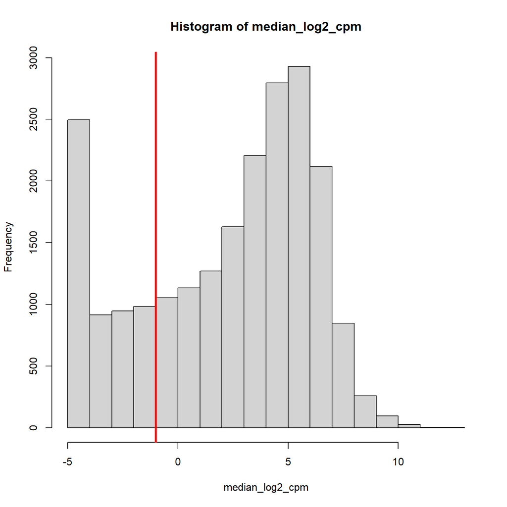

```r
cpm_log <- cpm(data_clean, log = TRUE)
median_log2_cpm <- apply(cpm_log, 1, median)
hist(median_log2_cpm)
expr_cutoff <- -1
abline(v = expr_cutoff, col = "red", lwd = 3)
```

```r
sum(median_log2_cpm > expr_cutoff)
```

```
## [1] 16371
```

```r
data_clean <- data_clean[median_log2_cpm > expr_cutoff, ]
```

After removing all genes with a median log<sub>2</sub> cpm below -1, we have 16371 genes remaining. A good rule of thumb when analyzing RNA-seq data from a single cell type is to expect 9-12 thousand expressed genes. In this case, we have many more because the samples include RNA collected from many different cell types, and thus it is not surprising that many more genes are robustly expressed.

**Question:** What are some ways that we could improve this simple cutoff? What information are we ignoring?

After filtering lowly expressed genes, we recalculate the log<sub>2</sub> cpm.

```r
cpm_log <- cpm(data_clean, log = TRUE)
```

We can also explore the relationships between the samples by visualizing a heatmap of the correlation matrix. The heatmap result corresponds to what we know about the data set. First, the samples in group A and B come from very different cell populations, so the two groups are very different. Second, since the samples in each group are technical replicates, the within group variance is very low.

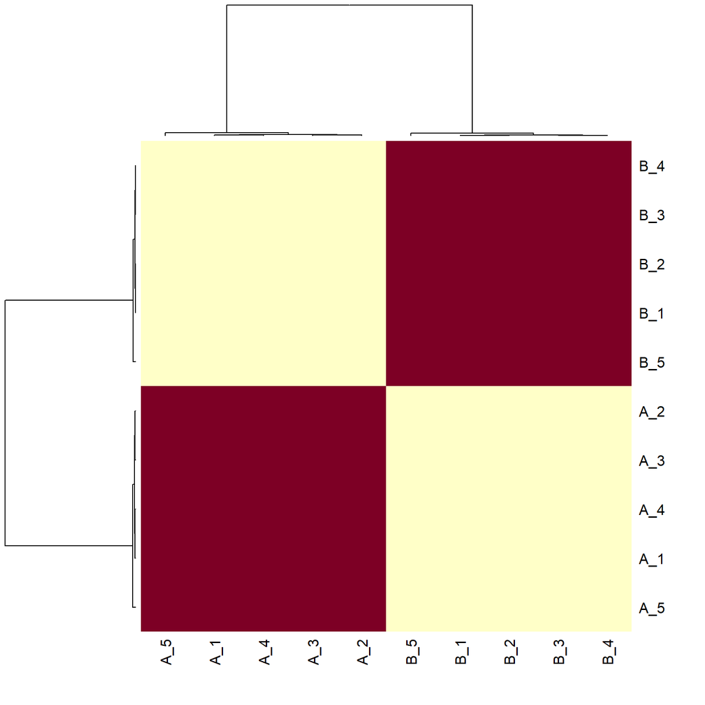

```r
heatmap(cor(cpm_log))
```

Another method to view the relationships between samples is principal components analysis (PCA).

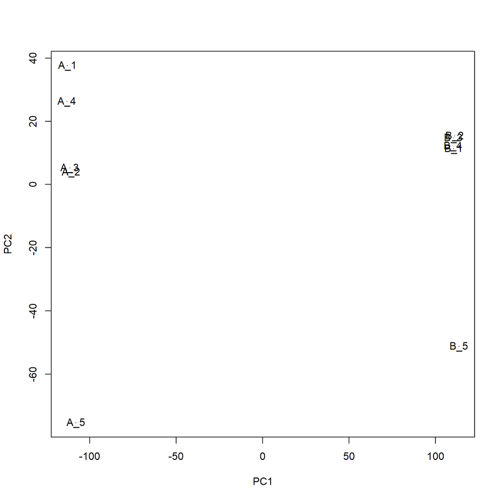

```r
pca <- prcomp(t(cpm_log), scale. = TRUE)
plot(pca$x[, 1], pca$x[, 2], pch = ".", xlab = "PC1", ylab = "PC2")
text(pca$x[, 1], pca$x[, 2], labels = colnames(cpm_log))
```

```r
summary(pca)
```

```
## Importance of components:
##                             PC1      PC2      PC3      PC4      PC5      PC6
## Standard deviation     117.3220 35.26093 24.78976 14.21437 12.51493 10.97288
## Proportion of Variance   0.8408  0.07595  0.03754  0.01234  0.00957  0.00735
## Cumulative Proportion    0.8408  0.91673  0.95427  0.96661  0.97618  0.98353
##                           PC7    PC8     PC9      PC10
## Standard deviation     9.9938 9.2222 9.20181 1.617e-13
## Proportion of Variance 0.0061 0.0052 0.00517 0.000e+00
## Cumulative Proportion  0.9896 0.9948 1.00000 1.000e+00
```

## Two group comparison

Now we start preparing the data for the the test of differential expression. We create a vector called, `group`, that labels each of the columns as belonging to group A or B. We then use this vector and the gene counts to create a DGEList, which is the object that edgeR uses for storing the data from a differential expression experiment.

```r
group <- substr(colnames(data_clean), 1, 1)
group
```

```
##  [1] "A" "A" "A" "A" "A" "B" "B" "B" "B" "B"
```

```r
y <- DGEList(counts = data_clean, group = group)
y
```

```
## An object of class "DGEList"
## $counts
##              A_1  A_2 A_3  A_4  A_5 B_1 B_2 B_3 B_4 B_5
## 1/2-SBSRNA4   74   51  36   66   34  39  41  33  35  18
## A1BG         194  315 195  274  456 138 128 175 147 171
## A1BG-AS1     128  129  79  145   82 115 137 100 102  45
## A1CF        1360 1139 780 1552 1011   6   7   3   3   2
## A2LD1        161  144  98  247  166 101  79 115  99  82
## 16366 more rows ...
##
## $samples
##     group lib.size norm.factors
## A_1     A 63518286            1
## A_2     A 58473717            1
## A_3     A 39099712            1
## A_4     A 78490525            1
## A_5     A 48611262            1
## B_1     B 62749592            1
## B_2     B 65979710            1
## B_3     B 66142599            1
## B_4     B 55042500            1
## B_5     B 37726512            1
```

edgeR normalizes the genes counts using the method TMM (trimmed means of m values) developed by Robinson and Oshlack (2010). Recall from lecture that the read counts for moderately to lowly expressed genes can be strongly influenced by small fluctuations in the expression level of highly expressed genes. In other words, small differences in expression of highly expressed genes between samples can give the appearance that many lower expressed genes are differentially expressed between conditions. TMM adjusts for this by removing the extremely lowly and highly expressed genes and also those genes that are very different across samples. It then compares the total counts for this subset of genes between the two samples to get the scaling factor (this is a simplification). Similar to normalization methods for microarray data, this method assumes the majority of genes are not differentially expressed between any two samples.

```r
y <- calcNormFactors(y)
y$samples
```

```
##     group lib.size norm.factors
## A_1     A 63518286    1.0327337
## A_2     A 58473717    1.0425468
## A_3     A 39099712    1.0653268
## A_4     A 78490525    1.0186905
## A_5     A 48611262    1.0878793
## B_1     B 62749592    0.9551043
## B_2     B 65979710    0.9512470
## B_3     B 66142599    0.9576923
## B_4     B 55042500    0.9532482
## B_5     B 37726512    0.9484930
```

The next step is to model the variance of the read counts per gene. A natural method for modeling gene counts is the Poisson distribution. However, the Poisson assumes the mean and variance are identical, but it has been found empirically that the variance in RNA-seq measurements of gene expression are larger than the mean (termed “overdispersion”). So instead the negative binomial distribution is used, which has a dispersion parameter for modeling the increase in variance from a Poisson process. edgeR treats the Poisson variance as simple sampling variance, and refers to the dispersion estimate as the “biological coefficient of variation.” Though it should be mentioned that any technical biases are also included in this estimate. edgeR shares information across genes to determine a common dispersion. It extends this to a trended dispersion to model the mean-variance relationship (lowly expressed genes are typically more noisy). Lastly it calculates a dispersion estimate per gene and shrinks it towards the trended dispersion. The gene-specific (referred to in edgeR as tagwise) dispersion estimates are used in the test for differential expression.

```r
y <- estimateDisp(y)
```

```
## Using classic mode.
```

```r
sqrt(y$common.dispersion) # biological coefficient of variation
```

```
## [1] 0.1157873
```

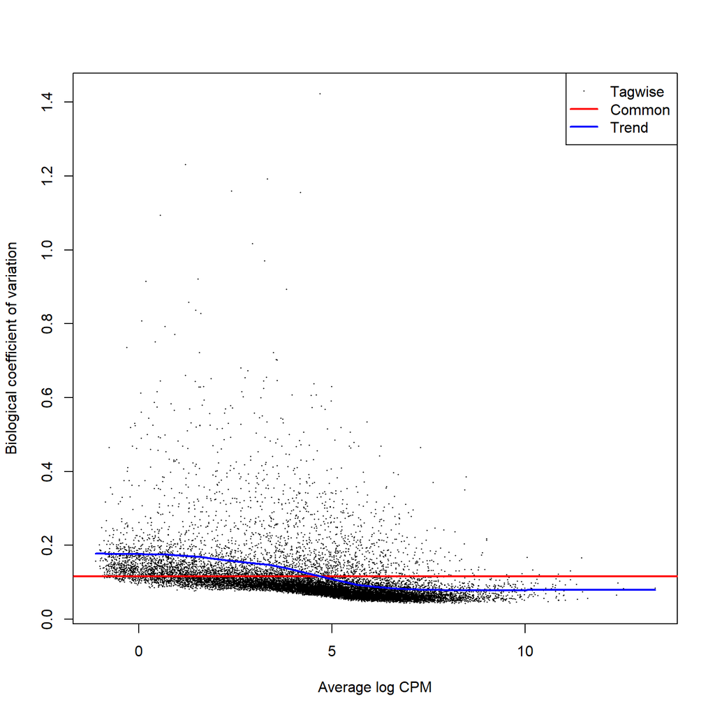

```r
plotBCV(y)
```

The biological coefficient of variation is lower than normally seen in human studies (~0.4) because the samples are technical replicates.

edgeR tests for differential expression between two classes using a method similar in idea to the Fisher’s Exact Test.

```r
et <- exactTest(y)
results_edgeR <- topTags(et, n = nrow(data_clean), sort.by = "none")
head(results_edgeR$table)
```

```
##                   logFC     logCPM        PValue           FDR
## 1/2-SBSRNA4 -0.51527936 -0.3725698  6.566658e-03  7.647088e-03
## A1BG        -0.76338290  1.9820174  1.323626e-02  1.518080e-02
## A1BG-AS1    -0.05741103  0.9017706  6.955820e-01  7.105562e-01
## A1CF        -7.94184292  3.2922591  0.000000e+00  0.000000e+00
## A2LD1       -0.60160567  1.1826171  3.976771e-04  4.850885e-04
## A2M         -1.60642410  8.8124410 1.297319e-196 7.405301e-196
```

How many genes are differentially expressed at an FDR of 10%?

```r
sum(results_edgeR$table$FDR < .1)
```

```
## [1] 14934
```

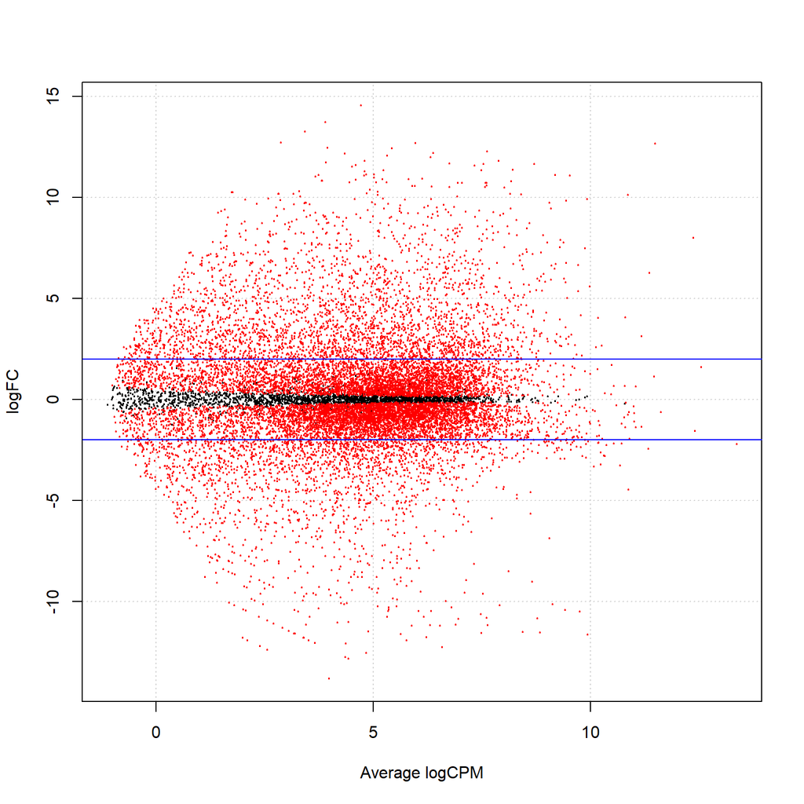

```r
plotSmear(et, de.tags = rownames(results_edgeR)[results_edgeR$table$FDR < .01])
abline(h = c(-2, 2), col = "blue")
```

## Adding covariates

The previous example was a two group comparison, but if you have additional covariates, you’ll need to use a generalized linear model (GLM) framework. Let’s say we processed the samples in two batches and also recorded the [RIN scores](http://www.genomics.agilent.com/article.jsp?pageId=2181&_requestid=506775) to control for differences in RNA quality.

```r
set.seed(123)
batch <- sample(c("one", "two"), 10, replace = TRUE)
rin <- sample(6:10, 10, replace = TRUE)
```

We need to create a design matrix to describe the statistical model.

```r
y <- DGEList(data_clean)
y <- calcNormFactors(y)
design <- model.matrix(~group + batch + rin)
design
```

```
##    (Intercept) groupB batchtwo rin
## 1            1      0        0   9
## 2            1      0        0   6
## 3            1      0        0   7
## 4            1      0        1   8
## 5            1      0        0  10
## 6            1      1        1   8
## 7            1      1        1   8
## 8            1      1        1   6
## 9            1      1        0   9
## 10           1      1        0   6
## attr(,"assign")
## [1] 0 1 2 3
## attr(,"contrasts")
## attr(,"contrasts")$group
## [1] "contr.treatment"
##
## attr(,"contrasts")$batch
## [1] "contr.treatment"
```

And now we test. The argument `coef = 2` corresponds to testing the second column of the design matrix, which in this case is whether the sample is from group A or B.

```r
y <- estimateDisp(y, design)
fit <- glmFit(y, design)
lrt <- glmLRT(fit, coef = 2)
topTags(lrt)
```

```
## Coefficient:  groupB
##               logFC    logCPM        LR PValue FDR
## C1QB       14.56743  4.713163  3246.549      0   0
## LINC00320  13.69255  3.885942  2177.743      0   0
## SLC17A6    13.25069  3.418738  1798.250      0   0
## MAGEA3    -12.89692  4.421769  2336.185      0   0
## MAGEA6    -12.82022  4.344894  2256.837      0   0
## CARTPT     12.72237  2.871257  1541.809      0   0
## GFAP       12.67005 11.477296 11726.685      0   0
## SPHKAP     12.66812  5.957807  5768.492      0   0
## NEUROD6    12.43813  3.934289  2270.489      0   0
## HBB        12.42367  5.415885  4283.239      0   0
```

And here is an example gene.

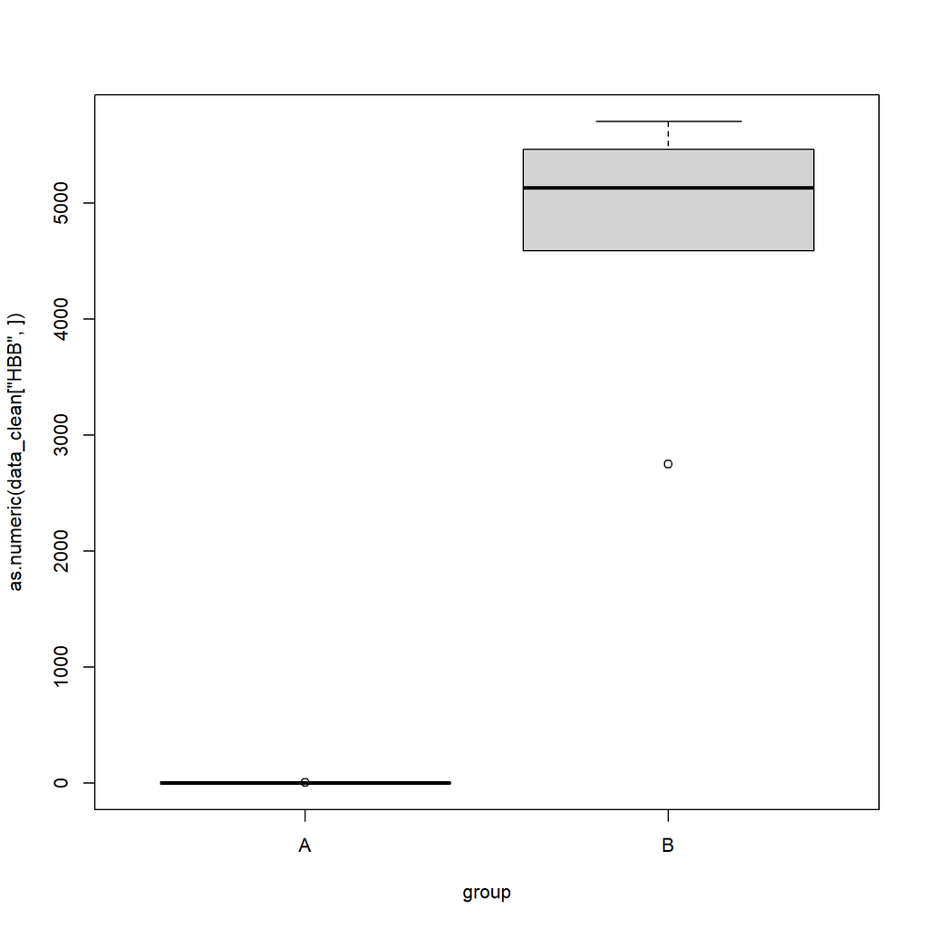

```r
boxplot(as.numeric(data_clean["HBB", ]) ~ group)
```

## To learn more

- Check out the manual for [edgeR](http://www.bioconductor.org/packages/release/bioc/vignettes/edgeR/inst/doc/edgeRUsersGuide.pdf) and search the Bioconductor [support site](https://support.bioconductor.org/).
- For a rigorous comparison of RNA-seq methods, see Rapaport, Khanin, Liang, Pirun, Krek, Zumbo, Mason, Socci, and Betel (2013) and Soneson and Delorenzi (2013).
- The [source code](https://gist.github.com/jdblischak/11384914) for this lesson is available as a GitHub Gist.
- In addition to [edgeR](http://www.bioconductor.org/packages/release/bioc/html/edgeR.html), there are many statistical tools available for performing differential expression analysis. Other commonly used count-based methods are [DESeq2](http://www.bioconductor.org/packages/release/bioc/html/DESeq2.html) and [limma+voom](http://www.bioconductor.org/packages/release/bioc/html/limma.html). For a different approach from the traditional count-based methods, check out [Cufflinks](http://cole-trapnell-lab.github.io/cufflinks/).

## References

[1] J. C. Marioni, C. E. Mason, S. M. Mane, et al. “RNA-seq: An assessment of technical reproducibility and comparison with gene expression arrays”. In: *Genome Research* 18.9 (jul.. 2008), pp. 1509-1517. DOI: 10.1101/gr.079558.108. <URL: https://doi.org/10.1101/gr.079558.108>.

[2] A. Oshlack, M. D. Robinson, and M. D. Young. “From RNA-seq reads to differential expression results”. In: *Genome Biology* 11.12 (2010), p. 220. DOI: 10.1186/gb-2010-11-12-220. <URL: https://doi.org/10.1186/gb-2010-11-12-220>.

[3] F. Rapaport, R. Khanin, Y. Liang, et al. “Comprehensive evaluation of differential gene expression analysis methods for RNA-seq data”. In: *Genome Biology* 14.9 (2013), p. R95. DOI: 10.1186/gb-2013-14-9-r95. <URL: https://doi.org/10.1186/gb-2013-14-9-r95>.

[4] M. D. Robinson, D. J. McCarthy, and G. K. Smyth. “edgeR: a Bioconductor package for differential expression analysis of digital gene expression data”. In: *Bioinformatics* 26.1 (nov.. 2009), pp. 139-140. DOI: 10.1093/bioinformatics/btp616. <URL: https://doi.org/10.1093/bioinformatics/btp616>.

[5] M. D. Robinson and A. Oshlack. “A scaling normalization method for differential expression analysis of RNA-seq data”. In: *Genome Biology* 11.3 (2010), p. R25. DOI: 10.1186/gb-2010-11-3-r25. <URL: https://doi.org/10.1186/gb-2010-11-3-r25>.

[6] M. D. Robinson and G. K. Smyth. “Moderated statistical tests for assessing differences in tag abundance”. In: *Bioinformatics* 23.21 (sep.. 2007), pp. 2881-2887. DOI: 10.1093/bioinformatics/btm453. <URL: https://doi.org/10.1093/bioinformatics/btm453>.

[7] C. Soneson and M. Delorenzi. “A comparison of methods for differential expression analysis of RNA-seq data”. In: *BMC Bioinformatics* 14.1 (mar.. 2013). DOI: 10.1186/1471-2105-14-91. <URL: https://doi.org/10.1186/1471-2105-14-91>.

[8] Z. Wang, M. Gerstein, and M. Snyder. “RNA-Seq: a revolutionary tool for transcriptomics”. In: *Nature Reviews Genetics* 10.1 (ene.. 2009), pp. 57-63. DOI: 10.1038/nrg2484. <URL: https://doi.org/10.1038/nrg2484>.